# Risk Predction_Analysis

Chathurika Hettiarachchige

November 11, 2018

This document consist of the code required to reproduce the analysis presented in the paper titled “Risk prediction system for dengue transmission based on high resolution weather data”.

We split the data set chronologically, such that approximately 75% of the data is assigned to the training set and the remaining to the test set. We choose the date to split the data such that it is a start of a week, which is also the closest to the date that splits the full data set as above.

The data collected before 2012-09-23 is considered as training set and the rest as test set.

# Stage 1: Predicting the Mosquito Presence

We performed a multivariate logistic regression to fit a model for the presence/absence 196 of larvae. Following is the multivariate logistic regression, and the treshold which maximises the sum of sensitivity and specificity. (Results for Table 1 on the paper.)

```
##
## Call:
## glm(formula = larvaB ~ MaxTemp + MaxPrecip + AvgRHumi + AvgHGT +
##     MaxTemp:AvgRHumi + MaxTemp:AvgHGT + MaxPrecip:AvgHGT + MaxPrecip:AvgRHumi +
##     MaxTemp:MaxPrecip + offset(Con), family = binomial(link = "logit"),
##     data = df2)
##
## Deviance Residuals:
##     Min       1Q   Median       3Q      Max
## -1.9739  -0.6431  -0.3648  -0.0756   3.6831
##
## Coefficients:
##                      Estimate Std. Error z value Pr(>|z|)
## (Intercept)         1.769e+02  1.776e+01   9.963  < 2e-16 ***
## MaxTemp            -6.091e-01  5.884e-02 -10.352  < 2e-16 ***
## MaxPrecip           7.917e-01  4.731e-01   1.673   0.0943 .
## AvgRHumi           -2.755e+00  2.232e-01 -12.340  < 2e-16 ***
## AvgHGT              1.150e-01  1.321e-02   8.703  < 2e-16 ***
## MaxTemp:AvgRHumi    9.244e-03  7.396e-04  12.498  < 2e-16 ***
## MaxTemp:AvgHGT     -4.093e-04  4.403e-05  -9.296  < 2e-16 ***
## MaxPrecip:AvgHGT   -3.070e-04  7.325e-05  -4.191 2.78e-05 ***
## MaxPrecip:AvgRHumi -9.453e-04  4.425e-04  -2.136   0.0327 *
## MaxTemp:MaxPrecip  -2.311e-03  1.459e-03  -1.584   0.1132
## ---
## Signif. codes:  0 '***' 0.001 '**' 0.01 '*' 0.05 '.' 0.1 ' ' 1
##
## (Dispersion parameter for binomial family taken to be 1)
##
##     Null deviance: 25383  on 30086  degrees of freedom
## Residual deviance: 22355  on 30077  degrees of freedom
## AIC: 22375
##
## Number of Fisher Scoring iterations: 9
```

The threshold level that maximises the sum of sensitivity and specificity is 0.179.

## Training set

The accuracy measures of the stage 1 model on the training set is as follows:

```
## [1] "Accuracy: 0.71"
```

```
## [1] "tpr(=sensitivity): 0.83"
```

```
## [1] "fpr(=1-specificity): 0.32"
```

```
## [1] "AUC: 0.755"
```

The predicted percentage of larvae positive locations in the divisions (Table 2) is as follows.

```
##       rownames(bb)  p_No p_Yes
## 7   Kaohsiung City 0.335 0.665
## 14     Tainan City 0.459 0.541
## 19   Yunlin County 0.605 0.395
## 1  Changhua County 0.674 0.326
## 12 Pingtung County 0.754 0.246
## 2      Chiayi City 0.782 0.218
## 13   Taichung City 0.824 0.176
## 3    Chiayi County 0.831 0.169
## 15     Taipei City 0.845 0.155
## 17    Taoyuan City 0.877 0.123
## 11 New Taipei City 0.973 0.027
## 6   Hualien County 0.978 0.022
## 9    Miaoli County 0.979 0.021
## 4     Hsinchu City 0.981 0.019
## 8     Keelung City 0.991 0.009
## 5   Hsinchu County 0.996 0.004
## 10   Nantou County 0.998 0.002
## 16  Taitung County 1.000 0.000
## 18    Yilan County 1.000 0.000
```

## Test set

The accuracy measures of the stage 1 model on the test set is as follows:

```
## [1] "Accuracy: 0.709"
```

```
## [1] "sensitivity(=tpr): 0.711"
```

```
## [1] "specificity(=1-fpr): 0.709"
```

```
## [1] "AUC: 0.71"
```

Wilcoxon test to compare the rank order of predictions in train and test sets:

```
##
##  Wilcoxon rank sum test with continuity correction
##
## data:  bb2$p_Yes and bb2_test$p_Yes
## W = 237, p-value = 0.09794
## alternative hypothesis: true location shift is not equal to 0
```

## Determine the threshold to classify the counties as positive

The threshold level to classify counties that maximises the sum of sensitivity and specificity is 0.21.

The accuracy measures of the classifying step:

```
## [1] "Threshold level: 0.21"
```

```
## [1] "Accuracy: 0.836"
```

```
## [1] "sensitivity(=tpr): 0.969"
```

```
## [1] "specificity(=1-fpr): 0.811"
```

Boxplots for the distribution of the percentage of larvae positive locations (Fig4):

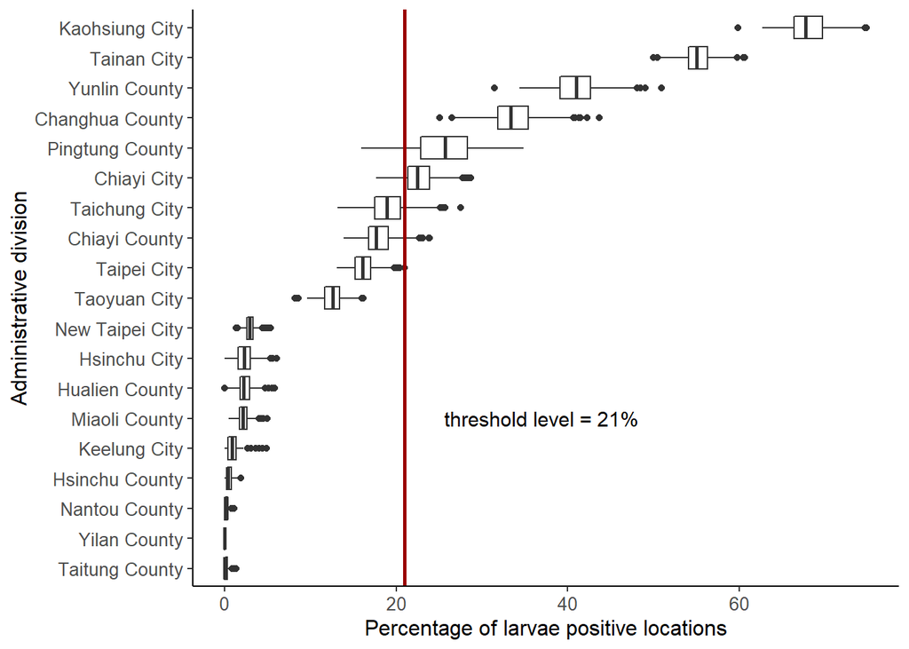

Maps of the percentages of Aedes aegypti larvae presence (Fig3):

For the trainining set:

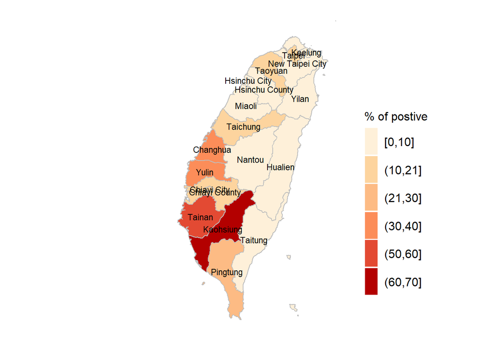

For the test set:

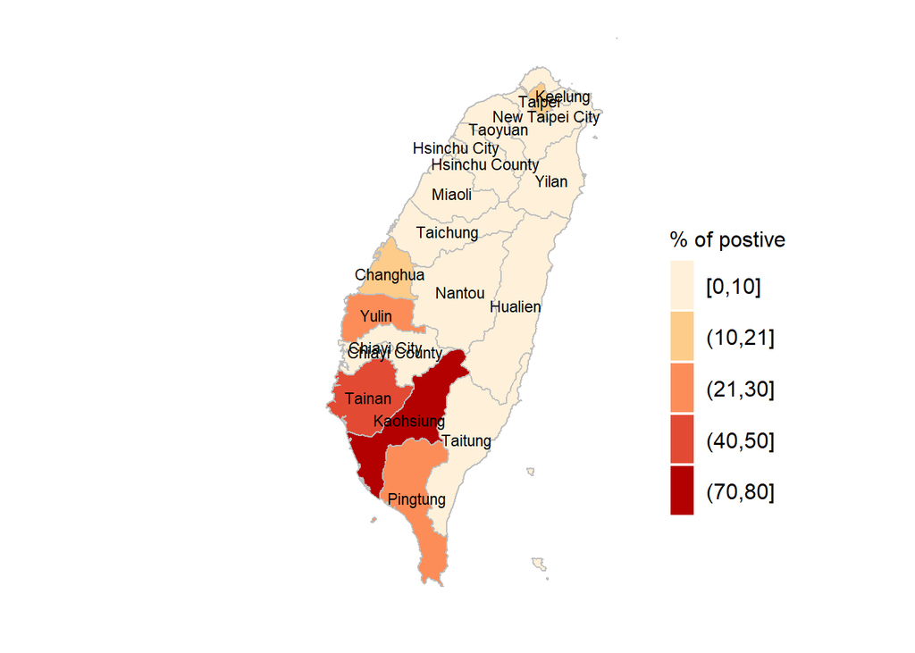

For the observed:

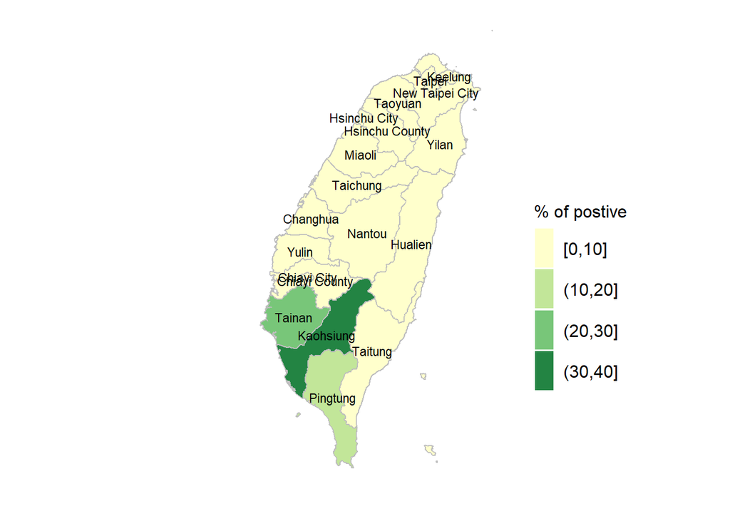

# Stage 2: Estimating the Mosquito Numbers

Here we fit a zero-inflated negative binomial model to estimate the mosquito numbers for the counties determined as positive in the Stage 1.

```
##
## Call:
## zeroinfl(formula = larva ~ MaxTemp + MaxPrecip + AvgRHumi + AvgHGT +
##     offset(Con), data = df, dist = "negbin", EM = TRUE)
##
## Pearson residuals:
##     Min      1Q  Median      3Q     Max
## -0.2911 -0.2887 -0.2788 -0.1417 58.4303
##
## Count model coefficients (negbin with log link):
##               Estimate Std. Error  z value Pr(>|z|)
## (Intercept) -3.979e+01  2.420e+00  -16.441   <2e-16 ***
## MaxTemp      1.150e-01  7.835e-03   14.676   <2e-16 ***
## MaxPrecip    5.375e-03  2.942e-03    1.827   0.0677 .
## AvgRHumi     5.072e-02  3.899e-03   13.010   <2e-16 ***
## AvgHGT      -3.430e-03  2.875e-04  -11.931   <2e-16 ***
## Log(theta)  -2.468e+00  1.806e-02 -136.619   <2e-16 ***
##
## Zero-inflation model coefficients (binomial with logit link):
##               Estimate Std. Error z value Pr(>|z|)
## (Intercept)  8.920e+01  5.518e+00  16.163  < 2e-16 ***
## MaxTemp     -2.854e-01  1.801e-02 -15.849  < 2e-16 ***
## MaxPrecip   -1.954e+03  4.890e+02  -3.997 6.42e-05 ***
## AvgRHumi    -9.204e-02  1.342e-02  -6.859 6.92e-12 ***
## AvgHGT      -2.717e-02  5.745e-03  -4.730 2.24e-06 ***
## ---
## Signif. codes:  0 '***' 0.001 '**' 0.01 '*' 0.05 '.' 0.1 ' ' 1
##
## Theta = 0.0848
## Number of iterations in BFGS optimization: 1
## Log-likelihood: -3.955e+04 on 11 Df
```

### Training set

Prediction intervals for the training set:

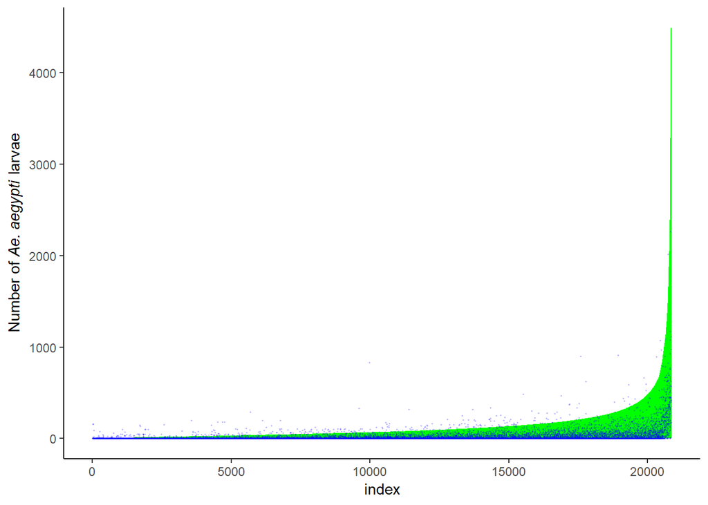

Coverage and MSE for the training set:

```
## [1] "coverage - zero inflated neg bin model (train set):  98.18"
```

```
## [1] "MSE (train set):  1809.9"
```

### Test set

Prediction intervals for the test set:

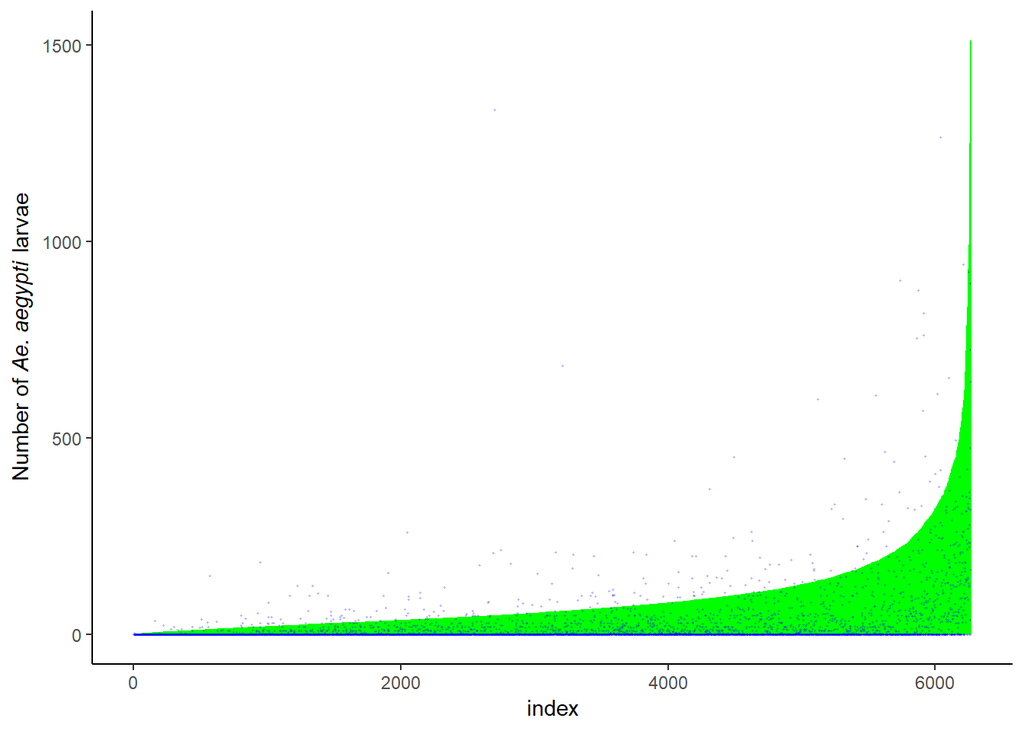

Coverage and MSE for the test set:

```
## [1] "coverage - zero inflated neg bin model (test set):  96.36"
```

```
## [1] "MSE (train set):  2364.6"
```

### Weekly predictions

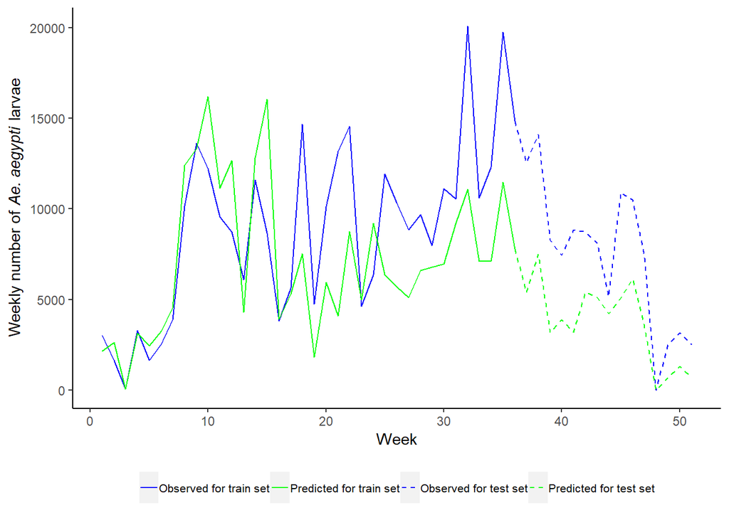

## Other supporting information

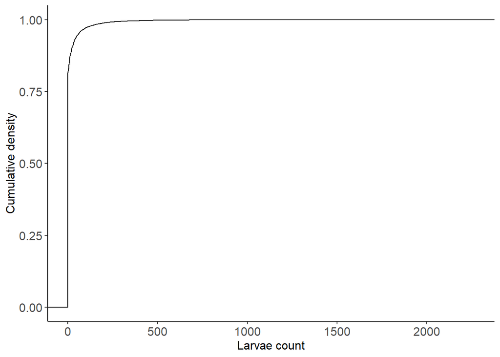

Model comparison:

```
## Likelihood ratio test
##
## Model 1: larva ~ MaxTemp + MaxPrecip + AvgRHumi + AvgHGT + offset(Con)
## Model 2: larva ~ MaxTemp + MaxPrecip + AvgRHumi + AvgHGT + offset(Con)
##   #Df  LogLik Df  Chisq Pr(>Chisq)
## 1   5 -392729
## 2   6 -114914  1 555631  < 2.2e-16 ***
## ---
## Signif. codes:  0 '***' 0.001 '**' 0.01 '*' 0.05 '.' 0.1 ' ' 1
```

```
## NA or numerical zeros or ones encountered in fitted probabilities
## dropping these 24 cases, but proceed with caution
## Vuong Non-Nested Hypothesis Test-Statistic:
## (test-statistic is asymptotically distributed N(0,1) under the
##  null that the models are indistinguishible)
## -------------------------------------------------------------
##               Vuong z-statistic             H_A    p-value
## Raw                    57.26591 model1 > model2 < 2.22e-16
## AIC-corrected          57.26591 model1 > model2 < 2.22e-16
## BIC-corrected          57.26591 model1 > model2 < 2.22e-16
## NULL
```

```
## NA or numerical zeros or ones encountered in fitted probabilities
## dropping these 24 cases, but proceed with caution
## Vuong Non-Nested Hypothesis Test-Statistic:
## (test-statistic is asymptotically distributed N(0,1) under the
##  null that the models are indistinguishible)
## -------------------------------------------------------------
##               Vuong z-statistic             H_A    p-value
## Raw                    56.55711 model1 > model2 < 2.22e-16
## AIC-corrected          56.55574 model1 > model2 < 2.22e-16
## BIC-corrected          56.55029 model1 > model2 < 2.22e-16
## NULL
```

```
## Vuong Non-Nested Hypothesis Test-Statistic:
## (test-statistic is asymptotically distributed N(0,1) under the
##  null that the models are indistinguishible)
## -------------------------------------------------------------
##               Vuong z-statistic             H_A    p-value
## Raw                    7.266359 model1 > model2 1.8463e-13
## AIC-corrected          6.992831 model1 > model2 1.3469e-12
## BIC-corrected          5.906269 model1 > model2 1.7497e-09
## NULL
```

```
## NA or numerical zeros or ones encountered in fitted probabilities
## dropping these 12 cases, but proceed with caution
## Vuong Non-Nested Hypothesis Test-Statistic:
## (test-statistic is asymptotically distributed N(0,1) under the
##  null that the models are indistinguishible)
## -------------------------------------------------------------
##               Vuong z-statistic             H_A    p-value
## Raw                    30.92073 model1 > model2 < 2.22e-16
## AIC-corrected          30.92073 model1 > model2 < 2.22e-16
## BIC-corrected          30.92073 model1 > model2 < 2.22e-16
## NULL
```